# TP 0 : Rappels de R

Auteur·rice

Zaineb Smida

## 1 Importation et manipulation de données

- Pour importer un fichier texte sous **R**, on utilise la fonction `read.table()`. Si la première ligne du fichier contient le nom des variables, on utilise l’option `header=T`. Par ailleurs, le paramètres `sep =` indique le caractère qui sépare les colonnes.

```r
regions <- read.table("data/regions.txt", header = TRUE)
```

L’objet créé est de type `data.frame` : les observations sont en lignes et les variables en colonnes. Un tel objet, contrairement à des matrices, peut contenir à la fois des variables quantitatives et qualitatives.

La fonction `str()` peut s’appliquer sur tous les types d’objets. Quand on l’applique sur un `data.frame`, elle permet de reprérer les variables quantatives (`numeric`, `integer`) et les variables qualitatives (`character` et ou `factor`):

```r
str(regions)
```

```
'data.frame':   21 obs. of  9 variables:
 $ NOM   : chr  "A" "Q" "U" "N" ...
 $ REGION: chr  "Alsace" "Aquitain" "Auvergne" "Bas-Norm" ...
 $ POPUL : int  1624 2795 1320 1390 1600 2795 2370 1340 1090 1730 ...
 $ TACT  : num  39.1 36.6 37.5 38.6 38.3 ...
 $ SUPERF: int  8280 41308 26013 17589 31582 27208 39151 25606 16202 12317 ...
 $ NBENTR: int  35976 85531 40494 35888 40714 73763 56753 24060 27481 37461 ...
 $ NBBREV: int  241 256 129 91 223 296 229 155 159 181 ...
 $ CHOM  : num  5.2 10.2 9.3 9 8.1 9.5 7.9 9.3 7.1 10.8 ...
 $ TELEPH: int  700 1300 600 600 750 1300 1100 550 450 750 ...
```

- On peut visualiser le tableau de données avec la fonction `View()` :

```r
View(regions)
```

- On obtient la taille du jeu de données avec la fonction `dim()` :

```r
dim(regions)
```

```
[1] 21  9
```

- Affichage des premières lignes du fichier :

```r
head(regions, 5)
```

```
  NOM   REGION POPUL  TACT SUPERF NBENTR NBBREV CHOM TELEPH
1   A   Alsace  1624 39.14   8280  35976    241  5.2    700
2   Q Aquitain  2795 36.62  41308  85531    256 10.2   1300
3   U Auvergne  1320 37.48  26013  40494    129  9.3    600
4   N Bas-Norm  1390 38.63  17589  35888     91  9.0    600
5   O Bourgogn  1600 38.26  31582  40714    223  8.1    750
```

équivalent à :

```r
regions[1:5, ]
```

```
  NOM   REGION POPUL  TACT SUPERF NBENTR NBBREV CHOM TELEPH
1   A   Alsace  1624 39.14   8280  35976    241  5.2    700
2   Q Aquitain  2795 36.62  41308  85531    256 10.2   1300
3   U Auvergne  1320 37.48  26013  40494    129  9.3    600
4   N Bas-Norm  1390 38.63  17589  35888     91  9.0    600
5   O Bourgogn  1600 38.26  31582  40714    223  8.1    750
```

- Affichage du nom des colonnes :

```r
names(regions)
```

```
[1] "NOM"    "REGION" "POPUL"  "TACT"   "SUPERF" "NBENTR" "NBBREV" "CHOM"
[9] "TELEPH"
```

- Sélection d’une colonne : on peut utiliser l’opérateur `$` suivi du nom de la variable à extraire. Le résultat est un vecteur :

```r
regions$POPUL
```

```
 [1]  1624  2795  1320  1390  1600  2795  2370  1340  1090  1730 10660  2110
[13]   720  2300  2430  3960  3060  1810  1590  4260  5350
```

- Sélection d’une ou plusieurs colonnes, soit par les indices de colonnes (attention, l’indice commence à 1 et pas 0 comme d’autres langages):

```r
regions[, c(1, 2)]
regions[, c("NOM" , "REGION")]
```

- On sélectionne toutes les colonnes sauf les colonnes 1 et 2

```r
regions[, -c(1, 2)]
```

## 2 Résumé statistique

La plupart des fonctions de **R** s’appliquent sur des vecteurs. On utilisera des fonctions différentes selon qu’il s’agit d’une variable quantitative ou qualitative.

### 2.1 Résumé statistique des variables quantitatives

Par exemple, pour calculer la moyenne de la variable `NBBREV`, on fait :

```r
mean(regions$NBBREV)
```

```
[1] 587.0952
```

Dans **R**, les valeurs manquantes sont codés des `NA`. Lorsqu’un vecteur contient des `NA`, le calcul de la moyenne ne sera pas possible sauf si on ajoute l’option `na.rm = T`. Cela est valable pour la plupart des fonctions ci-dessous :

- le minimum et le maximum :

```r
max(regions$NBBREV)
```

```
[1] 6722
```

```r
min(regions$NBBREV)
```

```
[1] 73
```

- la médiane et le quantile d’ordre $\alpha$ :

```r
median(regions$NBBREV)
```

```
[1] 223
```

```r
quantile(regions$NBBREV, 0.5)
```

```
50%
223
```

- l’écart-type et la variance :

```r
var(regions$NBBREV)
```

```
[1] 2063457
```

```r
sd(regions$NBBREV)
```

```
[1] 1436.474
```

Il est possible d’appliquer la même fonction sur plusieurs variables d’un jeu de données en utilisant la fonction `sapply()` de la façon suivante :

```r
sapply(regions[, 3:ncol(regions)], max)
```

```
    POPUL      TACT    SUPERF    NBENTR    NBBREV      CHOM    TELEPH
 10660.00     46.04  48698.00 273604.00   6722.00     13.20   5800.00
```

### 2.2 Résumé des variables qualitatives

Une variable qualitative est codée sous la forme d’un vecteur de `character` ou un `factor`. Par exemple, on créé une nouvelle variable qui vaut `"petit"` si la superficie est inférieure à 15000, `"moyenne"` si elle est comprise entre 15000 et 30000 et `"grande"` sinon

```r
regions$quali <- "moyenne"
regions$quali[regions$SUPERF < 15000] <- "petite"
regions$quali[regions$SUPERF >= 30000] <- "grande"
```

Sur une variable qualitative, on calcule en général la table de contingence, en utilisant la fonction `table()` :

```r
tab <- table(regions$quali)
tab
```

```
 grande moyenne  petite
      7      10       4
```

On calcule les proportions avec la fonction `prop.table()` :

```r
round(prop.table(tab), digits = 3)
```

```
 grande moyenne  petite
  0.333   0.476   0.190
```

On peut convertir la variable en `factor` si on est sûr du nombre de modalités possibles de la variable.

```r
regions$quali <- factor(regions$quali, levels = c("petite", "moyenne", "grande"))
```

### 2.3 Résumé globale

- La fonction `summary()` permet de calculer quelques résumés statistiques sur toutes les variables (quantitatives ou qualitatives) d’un jeu de données :

```r
summary(regions)
```

```
     NOM               REGION              POPUL            TACT
 Length:21          Length:21          Min.   :  720   Min.   :32.05
 Class :character   Class :character   1st Qu.: 1590   1st Qu.:36.62
 Mode  :character   Mode  :character   Median : 2110   Median :37.48
                                       Mean   : 2681   Mean   :37.23
                                       3rd Qu.: 2795   3rd Qu.:38.26
                                       Max.   :10660   Max.   :46.04
     SUPERF          NBENTR           NBBREV            CHOM
 Min.   : 8280   Min.   : 21721   Min.   :  73.0   Min.   : 5.200
 1st Qu.:16942   1st Qu.: 36285   1st Qu.: 155.0   1st Qu.: 7.900
 Median :25809   Median : 48353   Median : 223.0   Median : 9.300
 Mean   :25728   Mean   : 69827   Mean   : 587.1   Mean   : 9.186
 3rd Qu.:31582   3rd Qu.: 78504   3rd Qu.: 278.0   3rd Qu.:10.100
 Max.   :48698   Max.   :273604   Max.   :6722.0   Max.   :13.200
     TELEPH         quali
 Min.   : 350   petite : 4
 1st Qu.: 700   moyenne:10
 Median : 950   grande : 7
 Mean   :1262
 3rd Qu.:1300
 Max.   :5800
```

- La fonction `cor()` permet de calculer la matrice de corrélation sur plusieurs variables quantitatives :

```r
cor(regions[, 3:9])
```

```
             POPUL        TACT       SUPERF      NBENTR     NBBREV        CHOM
POPUL   1.00000000  0.51376438  0.024369703  0.98101936  0.9213741 -0.07313003
TACT    0.51376438  1.00000000 -0.059255061  0.51571338  0.7084501 -0.69854149
SUPERF  0.02436970 -0.05925506  1.000000000  0.14929185 -0.1639580  0.06205849
NBENTR  0.98101936  0.51571338  0.149291848  1.00000000  0.8916071 -0.07804957
NBBREV  0.92137414  0.70845007 -0.163957955  0.89160714  1.0000000 -0.25657627
CHOM   -0.07313003 -0.69854149  0.062058491 -0.07804957 -0.2565763  1.00000000
TELEPH  0.99391186  0.55526402  0.004764791  0.98290899  0.9444463 -0.09833108
             TELEPH
POPUL   0.993911864
TACT    0.555264016
SUPERF  0.004764791
NBENTR  0.982908993
NBBREV  0.944446274
CHOM   -0.098331084
TELEPH  1.000000000
```

## 3 Quelques graphiques de base

### 3.1 Une variable quantitative

On peut utiliser l’histogramme. Il existe de nombreuses options pour customiser le graphique. Ici, on n’en présente que quelques-unes :

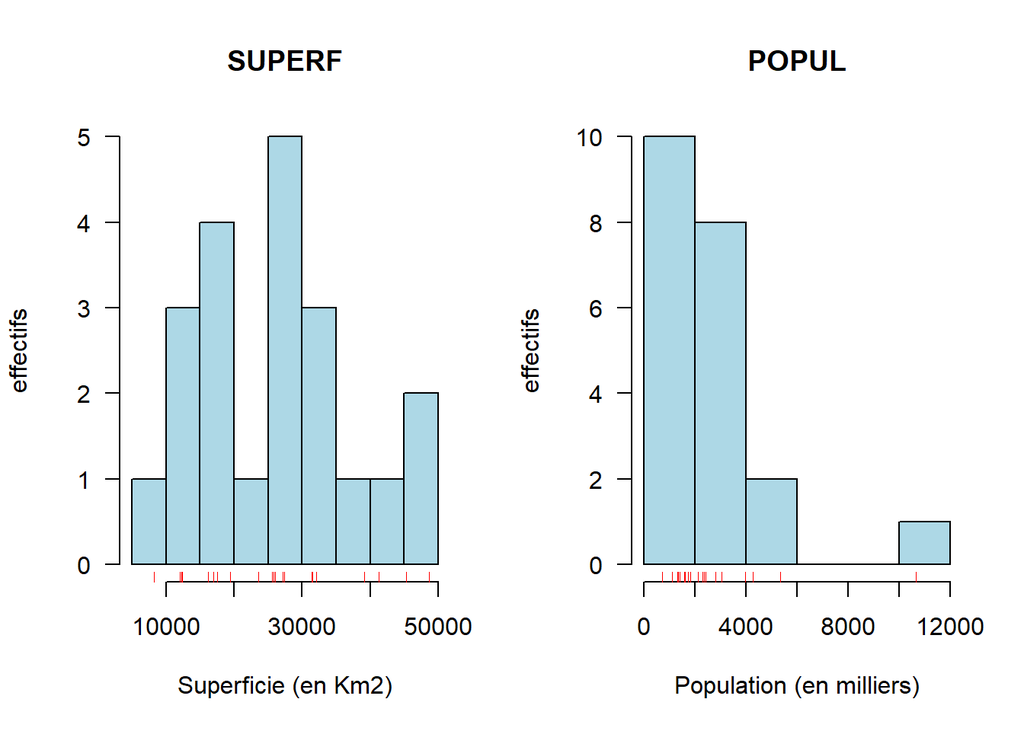

```r
par(mfrow = c(1, 2), # permet de représenter deux histogrammes dans 1 figure
  las = 1)         # l'échelle des ordonnées est écrit horizontalement
hist(regions$SUPERF,
     col = "lightblue",   # couleur de l'histogramme
     main = "SUPERF",     # titre
     xlab = "Superficie (en Km2)",  # légende sur l'axe des abscisses
     ylab = "effectifs") # légende sur l'axe des oronnées
rug(regions$SUPERF, col = "red") # représente les observations sur l'axe x

hist(regions$POPUL,
     col = "lightblue",
     main = "POPUL",
     xlab = "Population (en milliers)",ylab= "effectifs")
rug(regions$POPUL, col = "red")
```

Les boîtes à moustaches sont des alternatives et permettent plus facilement d’identifier les points atypiques :

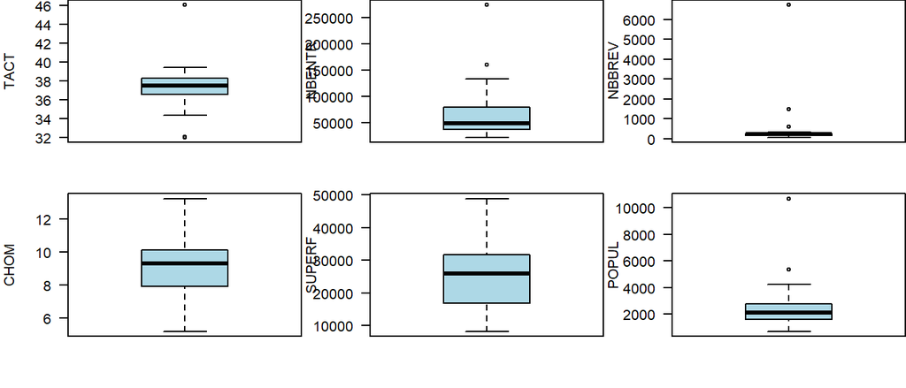

```r
par(mfrow = c(2, 3),  # Permet de représenter 6 boxplots dans 1 figure
    mar = c(3, 4, 0, 0), las = 1)  # Gère les marges et l'orientation des labels

# Création des boxplots avec des couleurs différentes pour chaque variable
boxplot(regions$TACT, ylab = "TACT", col = "lightblue")
boxplot(regions$NBENTR, ylab = "NBENTR", col = "lightblue")
boxplot(regions$NBBREV, ylab = "NBBREV", col = "lightblue")
boxplot(regions$CHOM, ylab = "CHOM", col = "lightblue")
boxplot(regions$SUPERF, ylab = "SUPERF", col = "lightblue")
boxplot(regions$POPUL, ylab = "POPUL", col = "lightblue")
```

### 3.2 Deux variables quantitatives

Pour étudier le lien entre deux variables quantitatives, on utilise le nuage de points :

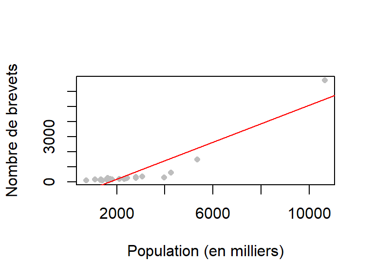

```r
plot(NBBREV ~ POPUL, # syntaxe de type formule y ~ x
     data = regions,
     pch = 16, # type de points
     cex = 0.8, # taille des points
     col = "grey", # couleur des points
     xlab = "Population (en milliers)",
     ylab = "Nombre de brevets"
     )
abline(lm(NBBREV ~ POPUL, data = regions), col = "red") # droite de régression linéaire
```

La fonction `pairs()` représente toutes les paires de nuage de points possible :

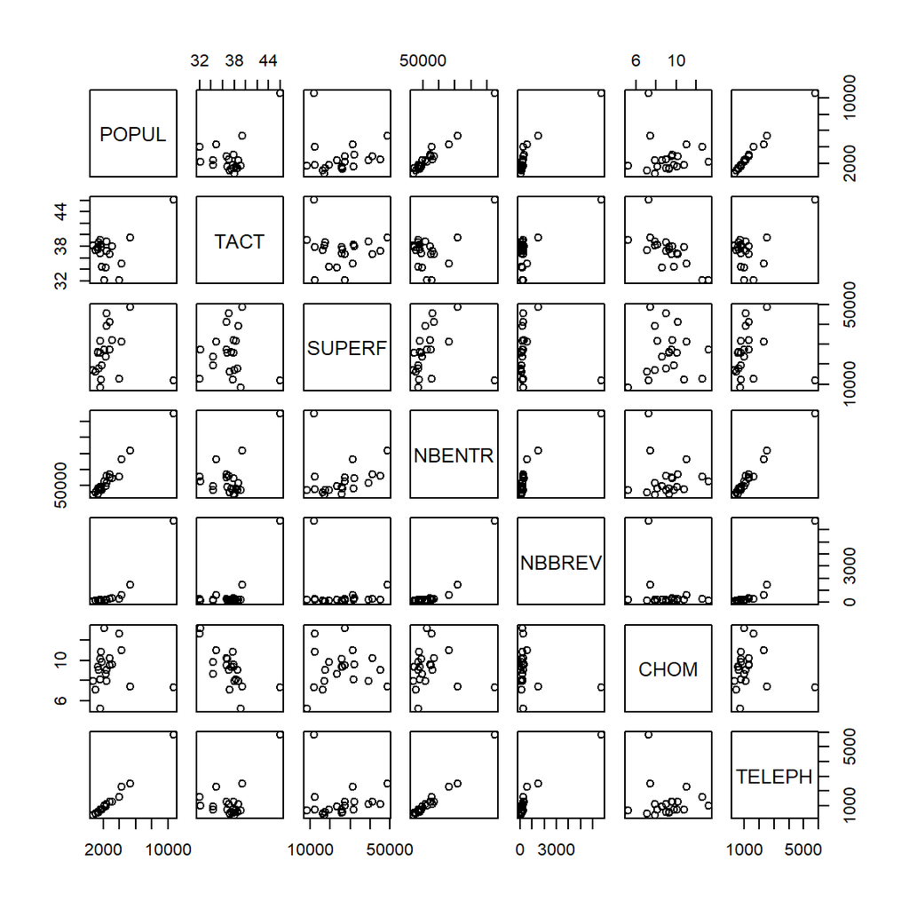

```r
pairs(regions[, 3:9])
```

### 3.3 Une variable qualitative

Pour les variables qualitatives, on utilise en général un diagramme en barres, qu’on applique sur la table de contingence :

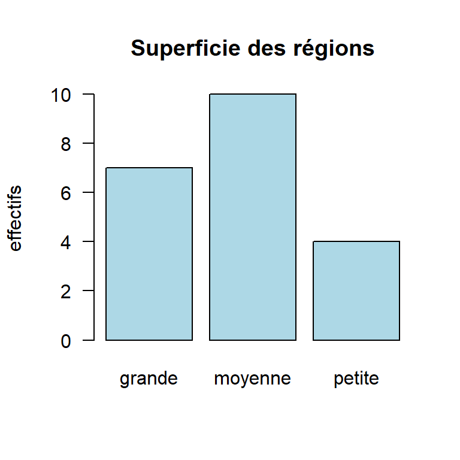

```r
par(las = 1)
barplot(tab, main = "Superficie des régions",
        ylab = "effectifs", col = "lightblue")
```

Si on on veut observer le lien entre deux variables qualitatives, on utilise également la fonction `barplot()`.

## 4 Autres fonctions utiles

- `setwd()` : pour changer le répertoire de travail
- `install.packages()` : installer des packages depuis le CRAN
- `library()` : charger une librairie au cours de la session

Référence utile : https://cran.r-project.org/doc/contrib/Paradis-rdebuts_fr.pdf